# AID Clase 2

## Ejemplo con distribución discreta binomial

```r
library(ggplot2)
n=100
p=0.25
x0=35
dbinom(x0,size=n,prob=p)#P(X=x0)=0.007019775
```

```
## [1] 0.007019775
```

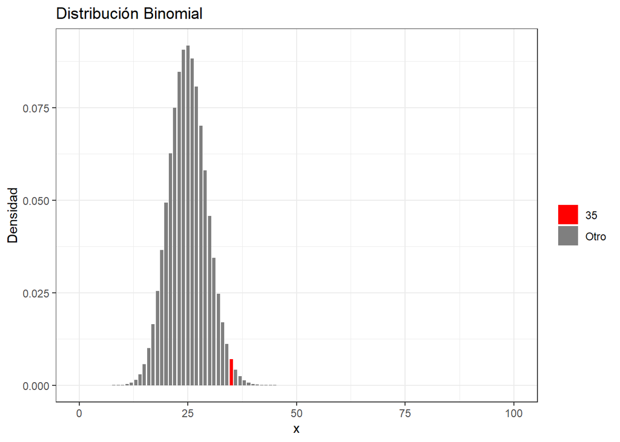

```r
rango = 0:n
df = data.frame(x = rango, y = dbinom(rango, size=n, prob=p))
ggplot(df, aes(x = x, y = y, fill=factor(ifelse(x==x0,toString(x0),"Otro")))) +
  geom_bar(stat = "identity",width = 0.75) + xlab("x") + ylab("Densidad") +
  ggtitle("Distribución Binomial") +
  scale_fill_manual(name = "", values=c("red", "grey50")) + theme_bw()
```

## Ejemplo cuando no se conoce la distribución de los datos

Retomando el ejemplo de datos de índice de masa corporal infantil, podemos calcular la probabilidad de que la edad sea menor o igual a 7.

```r
sum(EDAD<=7)/length(EDAD)
```

```
## [1] 0.4333333
```

# Teorema de Bayes

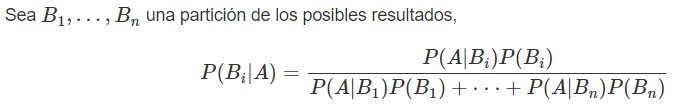

Supongamos que tenemos tres urnas: la urna roja (R) que contiene 15 bolas blancas y 10 negras; la urna verde (V) que contiene 10 bolas blancas y 17 negras; y la urna azul (A) que contiene 5 bolas blancas y 15 negras. Se solicita extraer de las urnas 1 bola.

#### **Ejercicio 1:** *Calcular la probabilidad de que la bola provenga de la urna R.*

#### **Ejercicio 2:** *Calcular la probabilidad de que la bola sea blanca y provenga de la urna R.*

#### **Ejercicio 3:** *Calcular la probabilidad de que, sabiendo que la bola extraída es de la urna A, sea negra.*

#### **Ejercicio 4:** *Calcular la probabilidad de que, sabiendo que la bola extraída es negra, provenga de la urna A.*

#### **Ejercicio 5:** *Suponiendo ahora que se extrajeron dos bolas, calcular la probabilidad de que, sabiendo que se extrajeron una bola blanca y luego una negra, la bola blanca provenga de la urna R y la negra provenga de la urna V.*